# Project 1

Here is my project.

```r
med <- read.csv("combinedData.csv", header = T)
```

> > > Here I read in my dataset.

```r
meds <- subset(med, (DRG.Definition %in% c("192 - CHRONIC OBSTRUCTIVE PULMONARY DISEASE W/O CC/MCC","293 - HEART FAILURE & SHOCK W/O CC/MCC","536 - FRACTURES OF HIP & PELVIS W/O MCC", "638 - DIABETES W CC")))
```

> > > It is also important to consider that different diagnoses are expected to have different costs - treating heartfailure is not going to cost the same as a broken leg. So in making this comparison, we will focus on thefollowing diagnoses that cover a range of different conditions that have different implications as to the hospitalstay required and the procedures necessary

> > > Here I subset my dataset into those where the DRG.Definition row falls into the various categories we are focusing on.

```r
meds$PatientPays<-meds$Average.Total.Payments-meds$Average.Medicare.Payments
meds$PctPatientPays<- meds$PatientPays / meds$Average.Total.Payments
```

> > > Here I create new variables in the data.frame that define the following: the absolute amount thepatient pays (PatientPays) and the percentage of the payment that is paid by the patient(PctPatientPays).

```r
meds$Urban <- factor(meds$Urban)
meds$regions <- factor(meds$regions)
meds$urbanByRegions <- meds$Urban:meds$regions
levels(meds$urbanByRegions)
```

```
 [1] "0:midwest"   "0:northeast" "0:south"     "0:west"      "1:midwest"   "1:northeast"
 [7] "1:south"     "1:west"      "2:midwest"   "2:northeast" "2:south"     "2:west"
[13] "3:midwest"   "3:northeast" "3:south"     "3:west"      "5:midwest"   "5:northeast"
[19] "5:south"     "5:west"
```

```r
table(meds$urbanByRegions)
```

```
  0:midwest 0:northeast     0:south      0:west   1:midwest 1:northeast     1:south      1:west
        663         535        1239         511          13          13          75           3
  2:midwest 2:northeast     2:south      2:west   3:midwest 3:northeast     3:south      3:west
        464         199        1010         154           0           2           4           0
  5:midwest 5:northeast     5:south      5:west
        612         625         784         499
```

> > > Here I create a factor variableurbanByRegionsin the data.frame that gives the cross ofUrbanandregions(e.g. rural, South, rural Northeast, etc.) by using the : command.

```r
meds <- droplevels(meds)
```

> > > Here I use drop levels to drop the levels with 0.

```r
summary(meds)
```

```
 Provider.State                                                DRG.Definition  Provider.Id
 CA     : 596   192 - CHRONIC OBSTRUCTIVE PULMONARY DISEASE W/O CC/MCC:2593   Min.   : 10001
 TX     : 592   293 - HEART FAILURE & SHOCK W/O CC/MCC                :2443   1st Qu.:110186
 FL     : 519   536 - FRACTURES OF HIP & PELVIS W/O MCC               :1103   Median :250069
 NY     : 459   638 - DIABETES W CC                                   :1762   Mean   :257006
 PA     : 399                                                                 3rd Qu.:390016
 IL     : 389                                                                 Max.   :670071
 (Other):4947
                  Provider.Name       Provider.City  Total.Discharges Average.Covered.Charges
 GOOD SAMARITAN HOSPITAL :  29   CHICAGO     :  81   Min.   : 11.00   Min.   :  3134
 MERCY MEDICAL CENTER    :  20   BALTIMORE   :  42   1st Qu.: 17.00   1st Qu.: 11352
 ST JOSEPH HOSPITAL      :  20   BROOKLYN    :  41   Median : 25.00   Median : 15544
 ST JOSEPH MEDICAL CENTER:  20   HOUSTON     :  41   Mean   : 33.47   Mean   : 18368
 MERCY HOSPITAL          :  19   PHILADELPHIA:  40   3rd Qu.: 41.00   3rd Qu.: 22070
 ST FRANCIS HOSPITAL     :  15   SPRINGFIELD :  37   Max.   :326.00   Max.   :130690
 (Other)                 :7778   (Other)     :7619
 Average.Total.Payments Average.Medicare.Payments Provider.Zip.Code      regions      Urban
 Min.   : 3144          Min.   : 2182             Min.   : 1040     midwest  :1842   0   :2948
 1st Qu.: 4212          1st Qu.: 3255             1st Qu.:27565     northeast:1469   1   : 104
 Median : 4711          Median : 3723             Median :44112     south    :3357   2   :1827
 Mean   : 5072          Mean   : 4093             Mean   :47812     west     :1233   3   :   6
 3rd Qu.: 5532          3rd Qu.: 4517             3rd Qu.:72342                      5   :2520
 Max.   :19512          Max.   :18613             Max.   :99701                      NA's: 496

  PatientPays      PctPatientPays        urbanByRegions
 Min.   :  261.2   Min.   :0.03898   0:south    :1239
 1st Qu.:  770.2   1st Qu.:0.15297   2:south    :1010
 Median :  898.4   Median :0.19230   5:south    : 784
 Mean   :  979.3   Mean   :0.19949   0:midwest  : 663
 3rd Qu.: 1059.3   3rd Qu.:0.23569   5:northeast: 625
 Max.   :10676.8   Max.   :0.74215   (Other)    :3084
                                     NA's       : 496
```

QUESTION 2

> > > PctPatientPays is the percentage each patient pays out of the total cost. This was made by taking the PatientPays and dividing it by the Total cost.

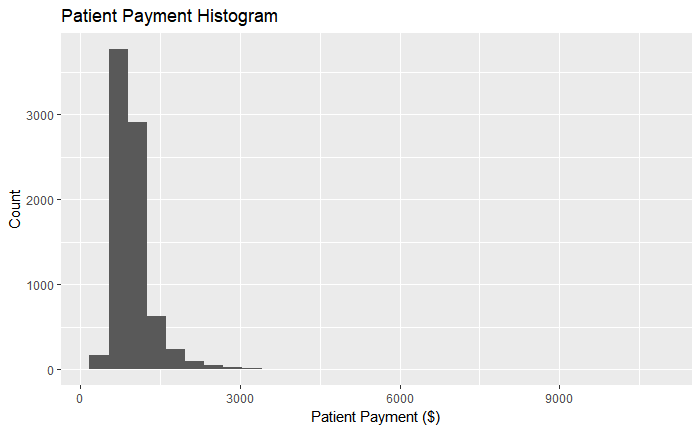

```r
library(ggplot2)
ggplot(meds, aes(x=PatientPays)) + geom_histogram() + labs(title= "Patient Payment Histogram",
                      y="Count", x = "Patient Payment ($)")
```

> > > Above is the histogram of Patient Payments. Though a transformation could help the histogram be more visually appealing, the information can be shown without one. A majority of Patient Payments are clustered near zero ($0 - $1500) then trickle down towards the higher range of numbers. This is an example of a right skew.

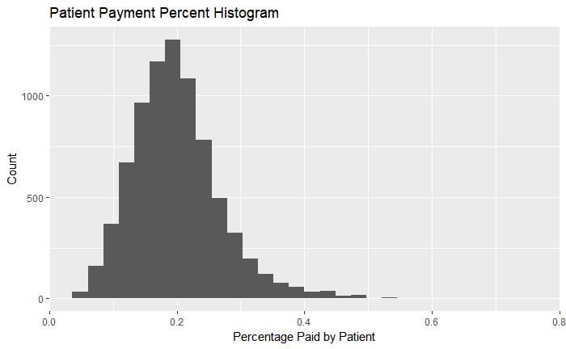

```r
ggplot(meds, aes(x=PctPatientPays)) + geom_histogram() + labs(title= "Patient Payment Percent Histogram",
                      y="Count", x = "Percentage Paid by Patient")
```

```r
contingency<-with(meds,table(Urban,regions))
contingency
```

```
     regions
Urban midwest northeast south west
    0     663       535  1239  511
    1      13        13    75    3
    2     464       199  1010  154
    3       0         2     4    0
    5     612       625   784  499
```

```r
medical <- subset(meds, (Urban %in% c("0","2","5")))
#SUbsetting the data into the different 4 diseases
lung <- subset(medical, medical$DRG.Definition == "192 - CHRONIC OBSTRUCTIVE PULMONARY DISEASE W/O CC/MCC")
heart<- subset(medical, medical$DRG.Definition == "293 - HEART FAILURE & SHOCK W/O CC/MCC")
hip <-subset(medical, medical$DRG.Definition == "536 - FRACTURES OF HIP & PELVIS W/O MCC")
diabetes<-subset(medical, medical$DRG.Definition == "638 - DIABETES W CC")
```

> > > Here we split up the data into the categories of each disease.

```r
unique(medical$urbanByRegions)
```

```
 [1] 5:west      2:west      0:west      0:south     5:south     2:south     0:northeast
 [8] 5:northeast 2:northeast 0:midwest   2:midwest   5:midwest
18 Levels: 0:midwest 0:northeast 0:south 0:west 1:midwest 1:northeast 1:south 1:west ... 5:west
```

```r
par(mfrow=c(3,4))
for (var in unique(lung$urbanByRegions)) {
    table <- subset(lung, medical$urbanByRegions == var)
    hist(table$PatientPays, main = var, xlab = "Amount Paid")
}
title("Patient Amount Paid for Lung",line = -.7, outer = TRUE)
```

[figure not shown]

```r
par(mfrow=c(3,4))
```

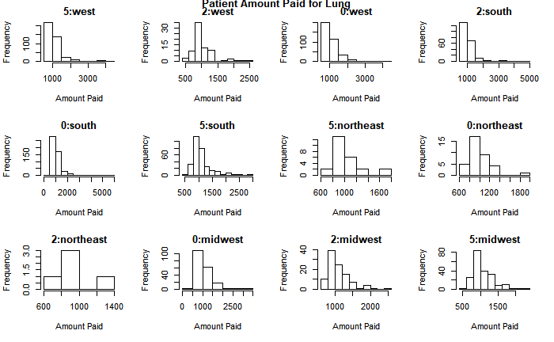

```r
for (var in unique(lung$urbanByRegions)) {
    table <- subset(lung, medical$urbanByRegions == var)
    hist(table$PatientPays, main = var, xlab = "Amount Paid")
}
title("Patient Amount Paid for Lung",line = -.7, outer = TRUE)
```